# Apply any R function on rolling windows

Dawid Kałędkowski

2026-01-30

## Using runner

`runner` package provides functions applied on running windows. The most universal function is `runner::runner` which gives user possibility to apply any R function `f` on running windows. Running windows are defined for each data window size `k`, `lag` with respect to their indexes. Unlike other available R packages, `runner` supports any input and output type and also gives full control to manipulate window size and lag/lead.

There are different kinds of running windows and all of them are implemented in `runner`.

### Cumulative windows

The simplest window type which is similar to `base::cumsum`. At each element window is defined by all elements appearing before current.

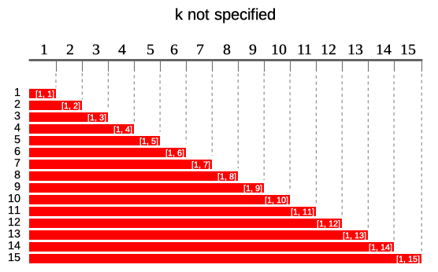

In `runner` this can be achieved as simple by:

```r
library(runner)
# full windows
runner(1:15)

# summarizing - sum
runner(
  1:15,
  f = sum
)

# summarizing - concatenating
runner(
  letters[1:15],
  f = paste,
  collapse = " > "
)
```

### Constant sliding windows

Second type of windows are these commonly known as running/rolling/moving/sliding windows. This types of windows moves along the index instead of cumulating like a previous one.  
Following diagram illustrates running windows of length `k = 4`. Each of 15 windows contains 4 elements (except first three).

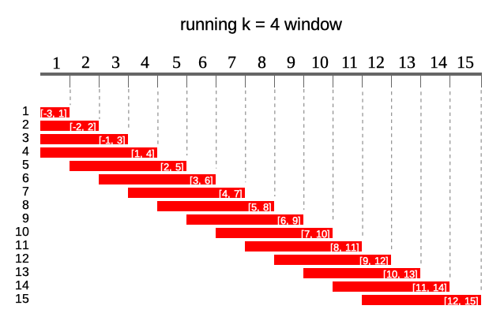

To obtain constant sliding windows one just needs to specify `k` argument

```r
# summarizing - sum of 4-elements
runner(
  1:15,
  k = 4,
  f = sum
)

# summarizing - slope from lm
df <- data.frame(
  a = 1:15,
  b = 3 * 1:15 + rnorm(15)
)

runner(
  x = df,
  k = 5,
  f = function(x) {
    model <- lm(b ~ a, data = x)
    coefficients(model)["a"]
  }
)
```

### Windows depending on date

By default `runner` calculates on assumption that index increments by one, but sometimes data points in dataset are not equally spaced (missing weekends, holidays, other missings) and thus window size should vary to keep expected time frame. If one specifies `idx` argument, than running functions are applied on windows depending on date rather on a sequence 1-n. `idx` should be the same length as `x` and should be of type `Date`, `POSIXt` or `integer`. Example below illustrates window of size `k = 5` lagged by `lag = 1`. Note that one can specify also `k = "5 days"` and `lag = "day"` as in `seq.POSIXt`.  
In the example below in square brackets ranges for each window.

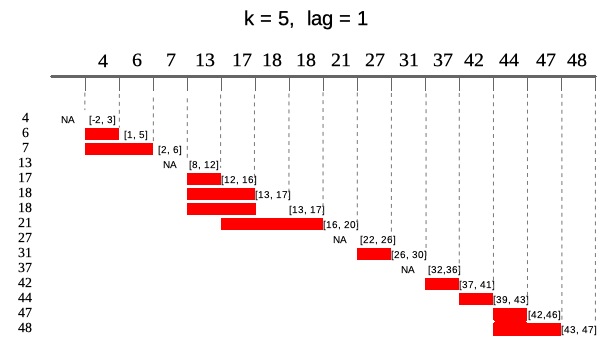

```r
idx <- c(4, 6, 7, 13, 17, 18, 18, 21, 27, 31, 37, 42, 44, 47, 48)

# summarize - mean
runner::runner(
  x = idx,
  k = 5, # 5-days window
  lag = 1,
  idx = idx,
  f = function(x) mean(x)
)


# use Date or datetime sequences
runner::runner(
  x = idx,
  k = "5 days", # 5-days window
  lag = 1,
  idx = Sys.Date() + idx,
  f = function(x) mean(x)
)

# obtain window from above illustration
runner::runner(
  x = idx,
  k = "5 days",
  lag = 1,
  idx = Sys.Date() + idx
)
```

### running at

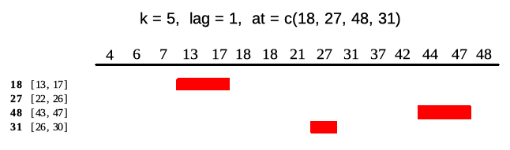

```r
idx <- c(4, 6, 7, 13, 17, 18, 18, 21, 27, 31, 37, 42, 44, 47, 48)

# summary
runner::runner(
  x = 1:15,
  k = 5,
  lag = 1,
  idx = idx,
  at = c(18, 27, 48, 31),
  f = mean
)

# full window
runner::runner(
  x = idx,
  k = 5,
  lag = 1,
  idx = idx,
  at = c(18, 27, 48, 31)
)
```

`at` can also be specified as interval of the output defined by time interval which results in obtaining results on following indices `seq(min(idx), max(idx), by = "<time interval>")`. Interval can be set in the same way as in `seq.POSIXt` function. It’s worth noting that `at` interval shouldn’t be more frequent than interval of `idx` - for `Date` the most frequent interval is a `"day"`, for `POSIXt` it’s a `"sec"`.

```r
idx_date <- seq(Sys.Date(), Sys.Date() + 365, by = "1 month")

# change interval to 4-months
runner(
  x = 0:12,
  idx = idx_date,
  at = "4 months"
)

# calculate correlation at every 6-months
runner(
  x = data.frame(
    a = 1:13,
    b = 1:13 + rnorm(13, sd = 5),
    idx_date
  ),
  idx = "idx_date",
  at = "6 months",
  f = function(x) {
    cor(x$a, x$b)
  }
)
```

### Move and stretch window in time

One can stretch window length by `k` and shift in time (or index) using `lag`. Both arguments can be `integer` and also time interval like for example `2 months`. If `k` or `lag` are a single value then window size/lag are constant for all elements of x. User can also specify `k/lag` as vector, then size and lag will vary for each window. Both `k` and `lag` can be of `length(.) == 1`, `length(.) == length(x)` or `length(.) == length(at)` (if `at` is specified). `lag` can be negative and positive while `k` only non-negative.

```r
# summarizing - concatenating
runner::runner(
  x = 1:10,
  lag = c(-1, 2, -1, -2, 0, 0, 5, -5, -2, -3),
  k = c(0, 1, 1, 1, 1, 5, 5, 5, 5, 5),
  f = paste,
  collapse = ","
)

# full window
runner::runner(
  x = 1:10,
  lag = 1,
  k = c(1, 1, 1, 1, 1, 5, 5, 5, 5, 5)
)

# on dates
idx <- c(4, 6, 7, 13, 17, 18, 18, 21, 27, 31, 37, 42, 44, 47, 48)

runner::runner(
  x = 1:15,
  lag = sample(c("-2 days", "-1 days", "1 days", "2 days"),
    size = 15,
    replace = TRUE
  ),
  k = sample(c("5 days", "10 days", "15 days"),
    size = 15,
    replace = TRUE
  ),
  idx = Sys.Date() + idx,
  f = function(x) mean(x)
)
```

### `NA` padding

Using `runner` one can also specify `na_pad = TRUE` which would return `NA` for any window which is partially out of range - meaning that there is no sufficient number of observations to fill the window. By default `na_pad = FALSE`, which means that incomplete windows are calculated anyway. `na_pad` is applied on normal cumulative windows and on windows depending on date. In example below two windows exceed range given by `idx` so for these windows are empty for `na_pad = TRUE`. If used sets `na_pad = FALSE` first window will be empty (no single element within `[-2, 3]`) and last window will return elements within matching `idx`.

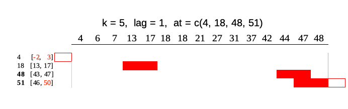

```r
idx <- c(4, 6, 7, 13, 17, 18, 18, 21, 27, 31, 37, 42, 44, 47, 48)

runner::runner(
  x = 1:15,
  k = 5,
  lag = 1,
  idx = idx,
  at = c(4, 18, 48, 51),
  na_pad = TRUE,
  f = function(x) mean(x)
)
```

### Using runner with `data.frame`

```r
x <- cumsum(rnorm(40))
y <- 3 * x + rnorm(40)
date <- Sys.Date() + cumsum(sample(1:3, 40, replace = TRUE)) # unequaly spaced time series
group <- rep(c("a", "b"), 20)

df <- data.frame(date, group, y, x)

slope <- runner(
  df,
  function(x) {
    coefficients(lm(y ~ x, data = x))[2]
  }
)

plot(slope)
```

[output not shown]

```r
library(dplyr)

summ <- df %>%
  group_by(group) %>%
  mutate(
    cumulative_mse = runner(
      x = .,
      k = "20 days",
      idx = "date", # specify column name instead df$date
      f = function(x) {
        coefficients(lm(y ~ x, data = x))[2]
      }
    )
  )

library(ggplot2)
summ %>%
  ggplot(aes(x = date, y = cumulative_mse, group = group, color = group)) +
  geom_line()
```

[output not shown]

When user executes multiple `runner` calls in `dplyr` mutate, one can also use `run_by` function to prespecify arguments in `tidyverse` pipeline. In the example below `runner` functions are applied on `k = "20 days"` calculated on `"date"` column.

```r
df %>%
  group_by(group) %>%
  run_by(idx = "date", k = "20 days", na_pad = FALSE) %>%
  mutate(
    cumulative_mse = runner(
      x = .,
      f = function(x) {
        mean((residuals(lm(y ~ x, data = x)))^2)
      }
    ),
    intercept = runner(
      x = .,
      f = function(x) {
        coefficients(lm(y ~ x, data = x))[1]
      }
    ),
    slope = runner(
      x = .,
      f = function(x) {
        coefficients(lm(y ~ x, data = x))[2]
      }
    )
  )
```

### Parallel mode

The `runner` function can also compute windows in parallel mode. The function doesn’t initialize the parallel cluster automatically but one have to do this outside and pass it to the `runner` through `cl` argument.

```r
library(parallel)

numCores <- detectCores()
cl <- makeForkCluster(numCores)

runner(
  x = df,
  k = 10,
  idx = "date",
  f = function(x) sum(x$x),
  cl = cl
)

stopCluster(cl)
```

*Executing `runner` in parallel mode isn’t always faster than a single thread.* *Multiple-thread computation generates some overhead due to managing the nodes.* *In general, complex functions which bases on processor (e.g. loops) used to be* *quicker in parallel mode but one should assess itself which option has the* *edge in specific situation.*

### Build-in functions

With `runner` one can use any R functions, but some of them are optimized for speed reasons. These functions are:  
- aggregating functions - `length_run`, `min_run`, `max_run`, `minmax_run`, `sum_run`, `mean_run`, `streak_run`  
- utility functions - `fill_run`, `lag_run`, `which_run`